# Primeira Análise Exploratória sobre Mortalidade por Psicoativos

Caroline de Oliveira, Franco Lovatti e Iane Martins

2024-07-01

## 1. Introdução ao problema

### 1.1 Variáveis utilizadas e fonte

Este relatório busca examinar as variáveis sociodemográficas presentes na base de dados do Sistema de Informação sobre Mortalidade (SIM) em relação às mortes por psicoativos ocorridas no Brasil e no estado do Espírito Santo entre os anos de 2013 e 2022. Para obter os dados desse tipo específico de morte, foram usados os Códigos Diagnósticos (CID) de F10 até F19.

As variáveis sociodemográficas selecionadas foram: Idade, Gênero, Raça, Escolaridade e Estado Civil. Aspectos como a quantidade de Mortes por Ano também foram incluídos no relatório para um melhor entendimento dos dados. Ao todo foram utilizadas quatro formas de dividir os dados: dados de mortes totais no Brasil, datos de mortes por psicoativos no Brasil, dados de mortes totais no Espírito Santo e dados de mortes por psicoativos no Espírito Santo.

## 3. Análise de correlação e Independência

## 4. Análise sociodemográfica

### 4.1 Gênero

A seguir é possível visualizar a discrepância entre o número de homens e de mulheres que morreram por mortes totais e por psicativos tanto no Brasil quando no Espírito Santo. Em ambas as localizações o número de óbitos de indivíduos do gênero masculino foi superior ao número de mortes em pessoas do gênero feminino. Ao observar a diferença entre as mortes totais e mortes por psicoativos, porém, tem-se que o número de homens que faleceram por uso de substância é consideravelmente superior ao número de mulheres. Ao mesmo tempo, enquanto o número de mortes em mulheres que morreram por uso de substãncia se mantêm bastante estável, os dados sobre os homens apresentam uma curva crescente de 2019 a 2021.

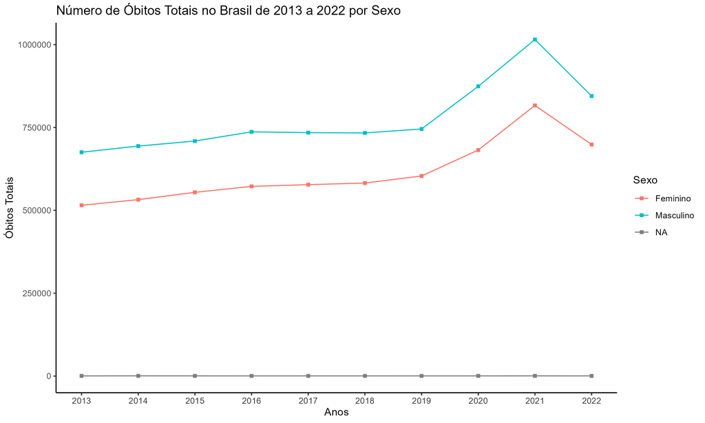

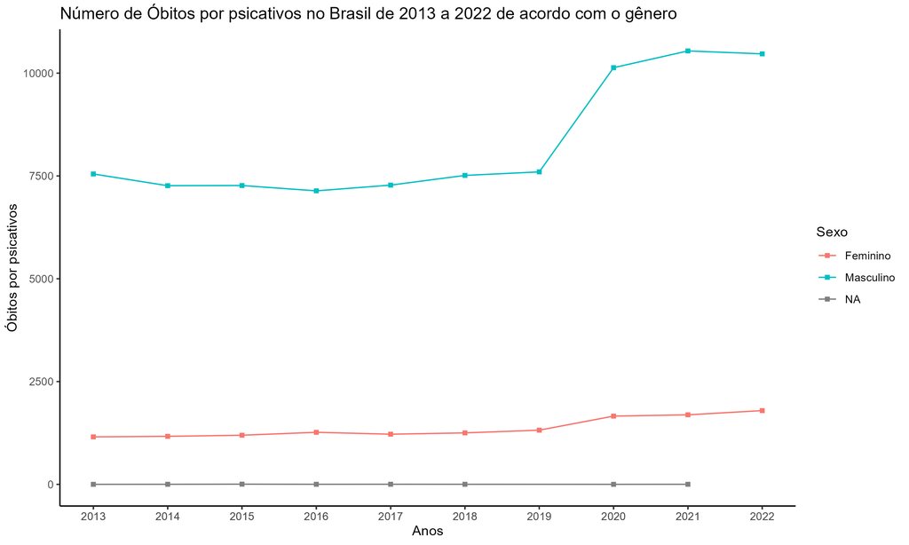

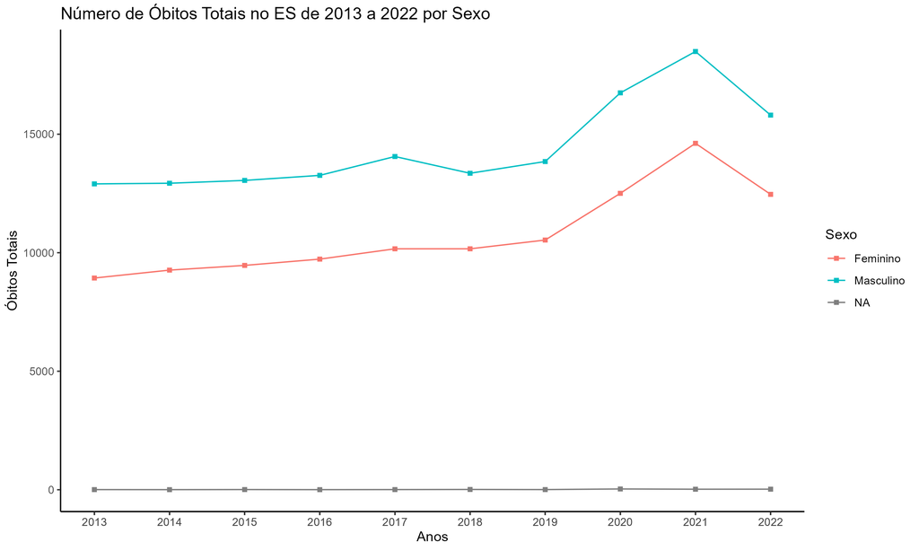

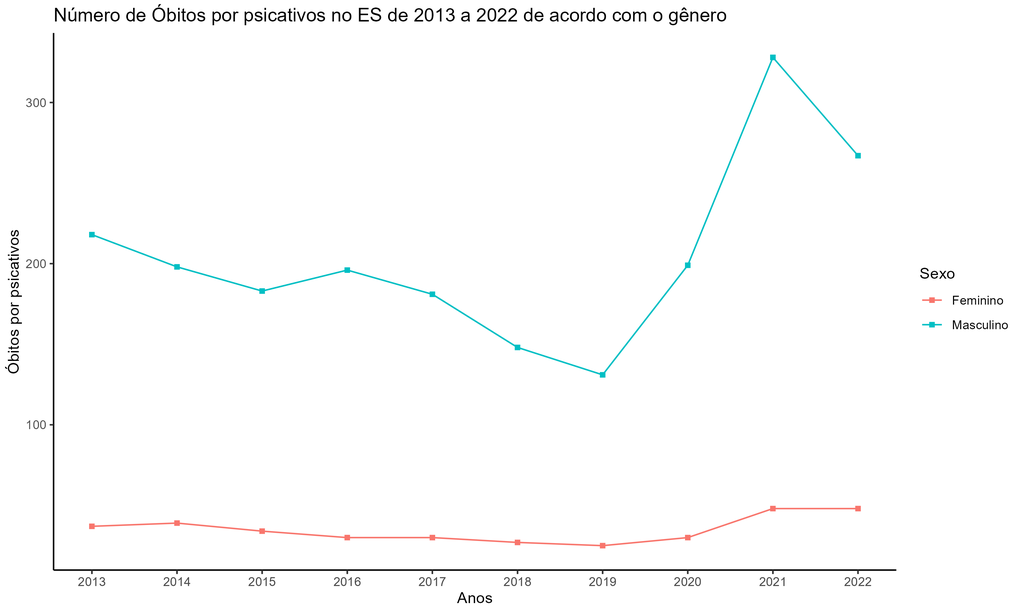

### 4.2 Idade

### 4.3 Raça

Os dados sobre as raças dos indivíduos falecidos no Brasil como um todo são bem parecidos com os dados do Espírito Santo. Em ambos os casos o número de mortes de pessoas brancas é superior ao número de mortes de pessoas pardas na maioria das vezes e sempre superior ao número de pessoas pretas, amarelas e indígenas. Entretanto, nas mortes por psicoativos o número de pardos é o predominante.

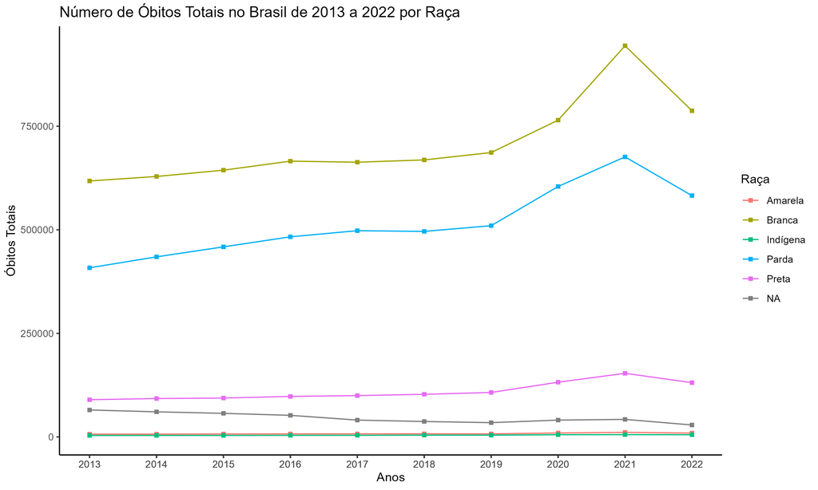

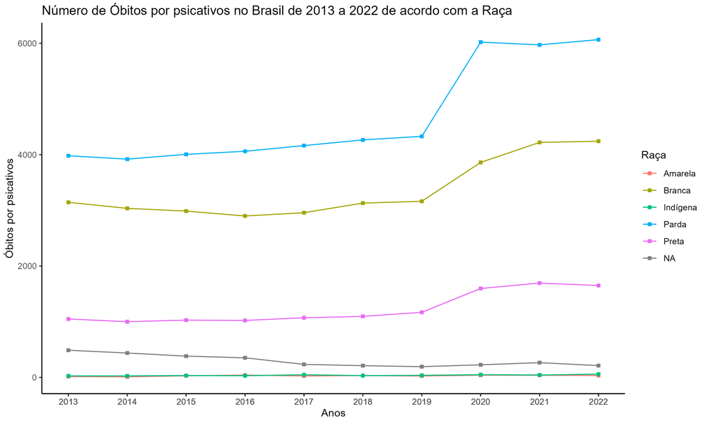

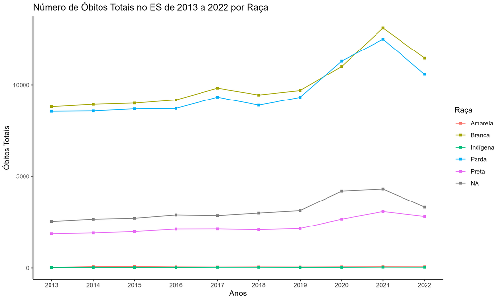

[figure not shown]

### 4.4 Escolaridade

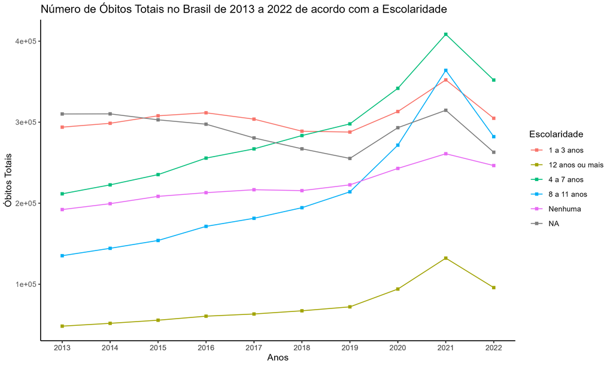

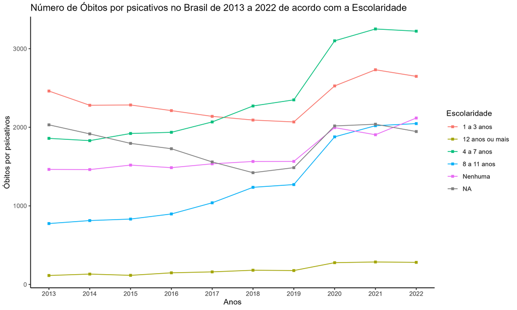

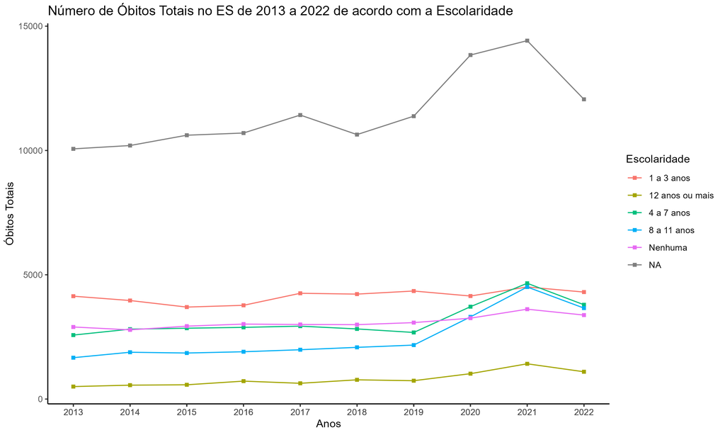

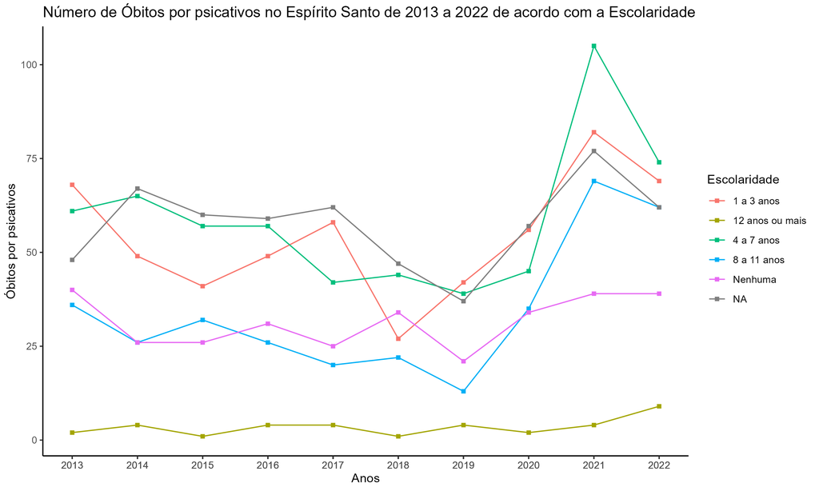

### 4.5 Estado civil

### 4.6 Local do óbito

## 5. Conclusões